# GeoAI for Fish Habitat Suitability Modeling

**Authors**: Jinyu Zhou, Zhe Zhang (Associate Professor)  
Cyberinfrastructure and Spatial Decision Intelligence Research Group  
https://www.cidigis.com  
Department of Geography  
Texas A&M University

### Learning Objectives

By the end of this notebook, you will be able to:

1. **Load & Explore** fisheries survey data from SEAMAP trawl surveys
2. **Use existing package to build a Geo AI Model** (XGBoost) to predict habitat suitability
3. **Interpret Results** using SHAP values to understand species-environment relationships
4. **Simulate Weather Ocean Environment Condition Change** to predict habitat shifts under environmental stress

### Case Study: Red Snapper in the Gulf of America

**Target Species:** Red Snapper (*Lutjanus campechanus*) - a high-value fishery species (~$100M+ annually) with well-documented habitat preferences and Environment sensitivity.

**Data:** https://seamapdata.gsmfc.org/ NOAA SEAMAP trawl surveys with in-situ environmental measurements (temperature, salinity, dissolved oxygen, depth).

## Section 1: Setup

Run this cell to import libraries and configure the study area.

```python
# Core libraries
import pandas as pd	# pandas is a library for data manipulation and analysis using dataframes
import numpy as np	# numpy provides support for large, multi-dimensional arrays and matrices, along with mathematical functions
import geopandas as gpd	# geopandas extends pandas to allow spatial operations on geometric data types
from shapely.geometry import Point	# shapely is a library for manipulation and analysis of planar geometric objects, with Point representing a single coordinate
from pathlib import Path	# pathlib offers an object-oriented approach for handling filesystem paths
import warnings	# warnings is a built-in module to manage warning messages
warnings.filterwarnings('ignore')	# disables showing warnings in the output

# Machine Learning
from sklearn.model_selection import train_test_split	# train_test_split in scikit-learn is used to split data arrays into random train and test subsets
from sklearn.metrics import roc_auc_score, classification_report, confusion_matrix, roc_curve	# these functions from scikit-learn provide tools for evaluating classification models
import xgboost as xgb	# xgboost is an optimized distributed gradient boosting library designed for high performance and efficiency
import shap	# shap is a library for interpreting machine learning models using SHAP values (SHapley Additive exPlanations)

# Visualization
import matplotlib.pyplot as plt	# matplotlib.pyplot is a collection of functions for creating static, interactive, and animated visualizations in Python
import seaborn as sns	# seaborn is a statistical data visualization library built on top of matplotlib

import plotly.express as px	# plotly.express is a high-level interface for creating interactive visualizations easily

# Set random seed for reproducibility
np.random.seed(42)
```

#### STUDY AREA CONFIGURATION

```python
# STUDY AREA CONFIGURATION
# Load Essential Fish Habitat (EFH) shapefile
EFH_SHAPEFILE = Path('shapefile-reef-fish-efh-gomex-sero/ReefFish_EFH_GOM.shp')	# defines the path to the Essential Fish Habitat (EFH) shapefile
EFH_GDF = gpd.read_file(EFH_SHAPEFILE)	# reads the EFH shapefile into a GeoDataFrame using geopandas
EFH_GDF = EFH_GDF.to_crs('EPSG:4326')	# converts the GeoDataFrame coordinate reference system to WGS84 latitude/longitude (EPSG:4326)

# Study bounds from EFH polygon
efh_bounds = EFH_GDF.total_bounds	# extracts the bounding coordinates (minx, miny, maxx, maxy) of all geometries in the GeoDataFrame
BOUNDS = {	# creates a dictionary containing the bounding box values for longitude and latitude
    'lon_min': efh_bounds[0], 'lon_max': efh_bounds[2],
    'lat_min': efh_bounds[1], 'lat_max': efh_bounds[3]
}

# Time period and target species
TIME_PERIOD = {'start': '2000-01-01', 'end': '2023-12-31'}	# specifies the time period for the study
TARGET_SPECIES = 'Lutjanus campechanus'	# scientific name of the target species (Red Snapper)
COMMON_NAME = 'Red Snapper'	# common name of the target species

# Create output directories
DATA_DIR = Path('data')	# defines the path where data files will be saved
FIG_DIR = Path('figures')	# defines the path where figures will be saved
for d in [DATA_DIR, FIG_DIR]:	# iterates over the list of output directory paths
    d.mkdir(parents=True, exist_ok=True)	# creates the required directories if they do not exist

print("Setup complete!")
print(f"Study area: Gulf of Mexico Reef Fish EFH")
print(f"Target: {COMMON_NAME} ({TARGET_SPECIES})")
print(f"Period: {TIME_PERIOD['start']} to {TIME_PERIOD['end']}")
```

```
Setup complete!
Study area: Gulf of Mexico Reef Fish EFH
Target: Red Snapper (Lutjanus campechanus)
Period: 2000-01-01 to 2023-12-31
```

## Section 2: Load & Explore Fish Survey Data

We use **SEAMAP trawl survey data** with species catch records and in-situ environmental measurements. we use **presence** (fish caught) and **absence** (fish not caught) records for habitat modeling.

### SEAMAP survey data overview

#### `starec.csv` – Station (tow) metadata

This file contains **one row per sampling event (“station” or tow)**, with information about where and when each tow occurred and how deep it was.

- **Key columns:**
  - `STATIONID`: numeric ID for the tow (a unique station/tow identifier).
  - `CRUISEID`: identifier for the cruise during which the tow was taken.
  - `DECSLAT`, `DECSLON`: starting latitude and longitude in decimal degrees.
  - `DEPTH_SSTA`: starting bottom depth at the station (meters).
  - `START_DATE`: datetime when the tow started.
- **Example rows (simplified):**

```
"STATIONID","CRUISEID","DECSLAT","DECSLON","DEPTH_SSTA","START_DATE"
"1","581","26.495","-96.505","147.2","11/10/2003 02:49:00"
"2","581","26.049","-96.471","119.4","11/10/2003 06:19:00"
"3","581","25.989","-96.985","51.8","11/10/2003 10:29:00"
```

We use this file to build the **set of stations**, filter them to our **time period**, and keep only those **inside the EFH polygon**.

#### `bgsrec.csv` – Biological catch records

This file contains **species-level catch information for each station**, with one row per species (or taxon group) per station.

- **Key columns:**
  - `STATIONID`: links each catch record back to its tow in `starec.csv`.
  - `BIO_BGS`: numeric “biocode” for the species/taxon.
  - `CNT`: raw count caught at the station.
  - `CNTEXP`: expanded (standardized) count, if available.
- **Example rows (simplified):**

```
"BGSID","CRUISEID","STATIONID","GENUS_BGS","SPEC_BGS","CNT","CNTEXP","BIO_BGS"
"1","581","4","RHIZOPR","TERRAE","1","1","108021802"
"2","581","4","SPHYRNA","TIBURO","5","5","108040104"
"7","581","4","SYNODUS","FOETEN","4","40","129040302"
```

In the code we:

- Filter `bgsrec` to rows where `BIO_BGS` matches the **Red Snapper biocode**.
- Sum `CNT`/`CNTEXP` (as `abundance`) **by `station_id`** to get total Red Snapper abundance per tow.
- Join that back to the station dataset to define **presence/absence**.

#### `envrec.csv` – Environmental measurements at stations

This file contains **environmental data associated with each station**, such as temperature, salinity, oxygen, and chlorophyll at different depths.

- **Key columns we use:**
  - `STATIONID`: links environmental measurements to the corresponding tow.
  - `TEMPSURF`, `TEMPMID`, `TEMPMAX`: temperature at surface, mid-water, and near-bottom.
  - `SALSURF`, `SALMID`, `SALMAX`: salinity at those same depths.
  - `OXYSURF`, `OXYMID`, `OXYMAX`: dissolved oxygen.
  - `CHLORSURF`, `CHLORMID`, `CHLORMAX`: chlorophyll concentration.
- **Example rows (simplified):**

```
"ENVRECID","CRUISEID","STATIONID","TEMPSURF","TEMPMID","TEMPMAX","SALSURF","SALMID","SALMAX","CHLORSURF","CHLORMID","CHLORMAX", "OXYSURF","OXYMID","OXYMAX"
"1","581","1","27.62","27.09","20.98","34.38","36.13","36.43", "1.9","15.99","3.57","5.7","5.3","4.4"
"2","581","2","27.56","27.62","24.08","31.96","36.02","36.43", "2.42","4.06","4.41","5.7","5.4","4.9"
```

We merge `envrec` into our station–fish dataset so that each tow in `fish_gdf` includes the **environmental conditions** at the time and place it was sampled.

### Load the Survey Data

```python
SEAMAP_DIR = Path('SEAMAPDATAV3CSV')	# Path is a pathlib object that defines the directory containing SEAMAP data files
RED_SNAPPER_BIOCODE = 170151107	# Sets the unique biocode integer for Red Snapper species

print("LOADING SEAMAP DATA")

# Step 1: Load Station Records
print("\n1. Loading station records...")
starec = pd.read_csv(SEAMAP_DIR / 'starec.csv')	# pandas is a data analysis library; reads the station records CSV into a DataFrame
starec = starec[['STATIONID', 'CRUISEID', 'DECSLAT', 'DECSLON', 'DEPTH_SSTA', 'START_DATE']].copy()	# Selects and copies columns relevant to station metadata from the DataFrame
starec.columns = ['station_id', 'cruise_id', 'latitude', 'longitude', 'depth_m', 'start_date']	# Renames the selected columns to use standardized lowercase names

starec['latitude'] = pd.to_numeric(starec['latitude'], errors='coerce')	# Converts latitude values to numeric, coercing errors to NaN for invalid entries
starec['longitude'] = pd.to_numeric(starec['longitude'], errors='coerce')	# Converts longitude values to numeric, coercing errors to NaN for invalid entries
starec['depth_m'] = pd.to_numeric(starec['depth_m'], errors='coerce')	# Converts depth values to numeric (meters), coercing errors to NaN
starec['date'] = pd.to_datetime(starec['start_date'], format='mixed', errors='coerce')	# Parses the start_date column to pandas datetime, allowing mixed date formats and coercing errors to NaT
starec = starec.dropna(subset=['latitude', 'longitude', 'date'])	# Removes rows with missing latitude, longitude, or date fields
print(f"   Loaded {len(starec):,} station records")
```

```
LOADING SEAMAP DATA

1. Loading station records...
   Loaded 61,384 station records
```

```python
# Step 2: Filter by time period
print("\n2. Filtering by time period...")
start_date = pd.to_datetime(TIME_PERIOD['start'])	# Converts the start date string in TIME_PERIOD to pandas datetime
end_date = pd.to_datetime(TIME_PERIOD['end'])	# Converts the end date string in TIME_PERIOD to pandas datetime
time_mask = (starec['date'] >= start_date) & (starec['date'] <= end_date)	# Creates a boolean mask to filter station records within the time period
starec = starec[time_mask].copy()	# Applies the time mask and makes a copy of the filtered DataFrame
print(f"   Stations in time period: {len(starec):,}")
```

```
2. Filtering by time period...
   Stations in time period: 31,132
```

```python
# Step 3: Filter by EFH polygon
print("\n3. Filtering by EFH polygon...")
geometry = [Point(lon, lat) for lon, lat in zip(starec.longitude, starec.latitude)]	# Point is a shapely geometry object; constructs a list of Point objects from longitude and latitude
starec_gdf = gpd.GeoDataFrame(starec, geometry=geometry, crs='EPSG:4326')	# geopandas reads tabular data as a GeoDataFrame with coordinate reference system set to WGS84
stations = gpd.sjoin(starec_gdf, EFH_GDF, predicate='within', how='inner')	# Performs a spatial join to retain only stations within the Essential Fish Habitat polygon
stations = stations.drop(columns=['index_right', 'Area_SqKm', 'Perim_M'], errors='ignore')	# Drops nonessential columns resulting from the spatial join if present
print(f"   Stations within EFH: {len(stations):,}")
```

```
3. Filtering by EFH polygon...
   Stations within EFH: 27,881
```

```python
# Step 4: Load Catch Records
print("\n4. Loading catch records...")
bgsrec = pd.read_csv(SEAMAP_DIR / 'bgsrec.csv', low_memory=False)	# Reads the catch records CSV file into a DataFrame, disabling low_memory mode for consistency
bgsrec = bgsrec[['STATIONID', 'BIO_BGS', 'CNT', 'CNTEXP']].copy()	# Selects relevant columns pertaining to catch counts and biological code
bgsrec.columns = ['station_id', 'biocode', 'count', 'count_expanded']	# Renames the columns for clarity and ease of use
bgsrec['abundance'] = bgsrec['count_expanded'].fillna(bgsrec['count'])	# Fills missing expanded counts with raw counts to compute total abundance
bgsrec['abundance'] = pd.to_numeric(bgsrec['abundance'], errors='coerce').fillna(0).astype(int)	# Ensures abundance is stored as numeric, filling invalid entries with zero and converting to integer
print(f"   Loaded {len(bgsrec):,} catch records")
```

```
4. Loading catch records...
   Loaded 891,280 catch records
```

```python
# Step 5: Filter for Red Snapper
print(f"\n5. Filtering for Red Snapper...")
target_catch = bgsrec[bgsrec['biocode'] == RED_SNAPPER_BIOCODE].copy()	# Filters catch records for rows with the Red Snapper biocode
target_by_station = target_catch.groupby('station_id')['abundance'].sum().reset_index()	# Aggregates abundance of Red Snapper by station using groupby and sum
print(f"   Found {len(target_catch):,} Red Snapper records")
```

```
5. Filtering for Red Snapper...
   Found 12,583 Red Snapper records
```

```python
# Step 6: Create presence/absence dataset
print("\n6. Create presence/absence dataset...")
fish_gdf = stations.merge(target_by_station, on='station_id', how='left')	# Merges the spatially filtered stations with Red Snapper catch data on station_id using a left join
fish_gdf['abundance'] = fish_gdf['abundance'].fillna(0).astype(int)	# Assigns a value of 0 to stations with missing abundance (no Red Snapper caught) and ensures integer type
fish_gdf['presence'] = (fish_gdf['abundance'] > 0).astype(int)	# Creates a binary column indicating presence (1) or absence (0) of Red Snapper
```

```
6. Create presence/absence dataset...
```

```python
# Step 7: Load Environmental Data
print("\n7. Loading environmental data...")
envrec = pd.read_csv(SEAMAP_DIR / 'envrec.csv', low_memory=False)	# Reads the environmental measurements CSV file into a DataFrame
env_cols = ['STATIONID', 'TEMPSURF', 'TEMPMID', 'TEMPMAX', 	# Specifies the list of columns to extract for environmental variables
            'SALSURF', 'SALMID', 'SALMAX',
            'OXYSURF', 'OXYMID', 'OXYMAX',
            'CHLORSURF', 'CHLORMID', 'CHLORMAX']
envrec = envrec[env_cols].copy()	# Selects only the relevant environmental columns
envrec.columns = ['station_id', 'temp_surf', 'temp_mid', 'temp_bot',	# Renames columns to concise, standardized names for downstream analysis
                  'sal_surf', 'sal_mid', 'sal_bot',
                  'oxy_surf', 'oxy_mid', 'oxy_bot',
                  'chl_surf', 'chl_mid', 'chl_bot']
for col in envrec.columns[1:]:	# Iterates over all environmental columns except station_id
    envrec[col] = pd.to_numeric(envrec[col], errors='coerce')	# Converts each environmental variable column to numeric, coercing errors to NaN

fish_gdf = fish_gdf.merge(envrec, on='station_id', how='left')	# Merges the environmental data into the fish GeoDataFrame based on station_id

# Summary
n_total = len(fish_gdf)	# Computes the total number of survey stations in the merged dataset
n_presence = fish_gdf['presence'].sum()	# Computes the total number of stations with Red Snapper present
print("DATA LOADED SUCCESSFULLY")
print(f"Total stations: {n_total:,}")
print(f"Presence: {n_presence:,} ({100*n_presence/n_total:.1f}%)")
print(f"Absence: {n_total - n_presence:,} ({100*(n_total-n_presence)/n_total:.1f}%)")
fish_gdf.head(5)	# Displays the first five rows of the final fish_gdf DataFrame for inspection
```

```
7. Loading environmental data...
DATA LOADED SUCCESSFULLY
Total stations: 27,922
Presence: 6,488 (23.2%)
Absence: 21,434 (76.8%)
```

|  | station_id | cruise_id | latitude | longitude | depth_m | start_date | date | geometry | abundance | presence | ... | temp_bot | sal_surf | sal_mid | sal_bot | oxy_surf | oxy_mid | oxy_bot | chl_surf | chl_mid | chl_bot |
| --- | --- | --- | --- | --- | --- | --- | --- | --- | --- | --- | --- | --- | --- | --- | --- | --- | --- | --- | --- | --- | --- |
| 0 | 1 | 581 | 26.495 | -96.505 | 147.2 | 11/10/2003 02:49:00 | 2003-11-10 02:49:00 | POINT (-96.50500 26.49500) | 0 | 0 | ... | 20.98 | 34.38 | 36.13 | 36.43 | 5.7 | 5.3 | 4.4 | 1.90 | 15.99 | 3.57 |
| 1 | 2 | 581 | 26.049 | -96.471 | 119.4 | 11/10/2003 06:19:00 | 2003-11-10 06:19:00 | POINT (-96.47100 26.04900) | 0 | 0 | ... | 24.08 | 31.96 | 36.02 | 36.43 | 5.7 | 5.4 | 4.9 | 2.42 | 4.06 | 4.41 |
| 2 | 4 | 581 | 26.086 | -97.094 | 18.3 | 11/10/2003 13:37:00 | 2003-11-10 13:37:00 | POINT (-97.09400 26.08600) | 26 | 1 | ... | 27.00 | 30.21 | 31.28 | 32.58 | 5.6 | 5.3 | 4.1 | 3.36 | 4.34 | 9.04 |
| 3 | 5 | 581 | 26.121 | -97.140 | 13.4 | 11/10/2003 15:19:00 | 2003-11-10 15:19:00 | POINT (-97.14000 26.12100) | 1 | 1 | ... | 26.84 | 30.41 | 31.10 | 31.66 | 5.6 | 4.6 | 4.2 | 3.22 | 9.27 | 9.35 |
| 4 | 6 | 581 | 26.222 | -97.155 | 13.5 | 11/10/2003 16:59:00 | 2003-11-10 16:59:00 | POINT (-97.15500 26.22200) | 0 | 0 | ... | 26.69 | 29.94 | 30.22 | 30.94 | 5.6 | 5.3 | 4.6 | 3.42 | 5.45 | 11.58 |

5 rows × 22 columns

### Visualize Survey Data

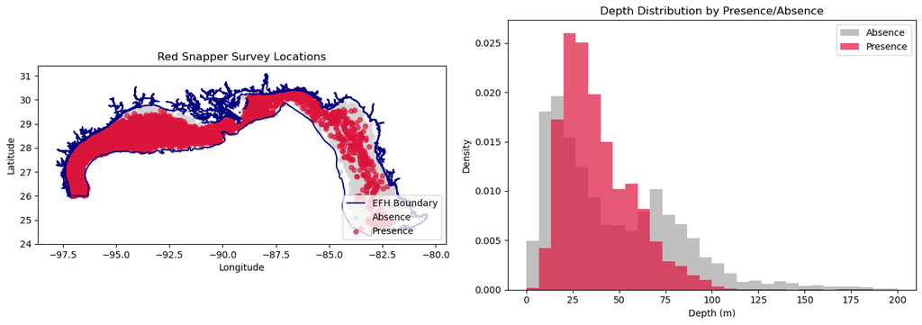

```
Total surveys: 27,922 | Presence: 6,488 (23.2%)
```

```python
# Visualize survey data
fig, axes = plt.subplots(1, 2, figsize=(14, 5))	# Creates a matplotlib figure with two subplot axes, with specified dimensions for plotting
presence = fish_gdf[fish_gdf['presence'] == 1]	# Filters the survey data for sites where Red Snapper were present
absence = fish_gdf[fish_gdf['presence'] == 0]	# Filters the survey data for sites where Red Snapper were absent

# Plot 1: Spatial distribution
ax1 = axes[0]	# Selects the first subplot axis for spatial plotting
EFH_GDF.boundary.plot(ax=ax1, color='navy', linewidth=1.5, label='EFH Boundary')	# Plots the Essential Fish Habitat boundary as a line on the map
ax1.scatter(absence.longitude, absence.latitude, c='lightgray', s=15, alpha=0.4, label='Absence')	# Plots absence points as light gray circles on the map
ax1.scatter(presence.longitude, presence.latitude, c='crimson', s=25, alpha=0.7, label='Presence')	# Plots presence points as crimson circles on the map
ax1.set_xlabel('Longitude'); ax1.set_ylabel('Latitude')	# Sets the x and y axis labels for spatial plot
ax1.set_title(f'{COMMON_NAME} Survey Locations')	# Sets the subplot title showing the fish common name
ax1.legend(loc='lower right')	# Adds a legend for the spatial plot in the lower right corner

# Plot 2: Depth distribution
ax2 = axes[1]	# Selects the second subplot axis for depth distribution
ax2.hist(absence['depth_m'], bins=30, alpha=0.5, label='Absence', color='gray', density=True, range=(0, 200))	# Plots a normalized histogram of depths for absence locations
ax2.hist(presence['depth_m'], bins=30, alpha=0.7, label='Presence', color='crimson', density=True, range=(0, 200))	# Plots a normalized histogram of depths for presence locations
ax2.set_xlabel('Depth (m)'); ax2.set_ylabel('Density')	# Sets x and y labels for the histogram plot
ax2.set_title('Depth Distribution by Presence/Absence')	# Assigns a title to the depth distribution plot
ax2.legend()	# Adds a legend to the depth distribution subplot

plt.tight_layout()	# Adjusts the layout to prevent overlap of subplots and labels
plt.savefig(FIG_DIR / 'fish_survey_exploration.png', dpi=150)	# Saves the generated figure as a PNG file in the figure output directory
plt.show()	# Displays the plots

print(f"Total surveys: {len(fish_gdf):,} | Presence: {len(presence):,} ({100*len(presence)/len(fish_gdf):.1f}%)")
```

## Section 3: Visualize Environmental Data

SEAMAP includes **in-situ environmental measurements** at each survey station: bottom temperature, salinity, dissolved oxygen, and depth. These are already joined to our fish data. Let's visualize how environmental conditions differ between presence and absence locations.

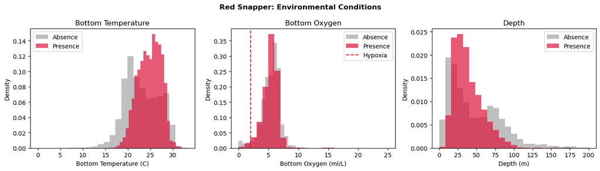

```
Key finding: Red Snapper occur at warmer bottom temps (24.8C vs 23.1C) and shallower depths (39m vs 48m)
```

```python
# Environmental conditions by presence/absence
fig, axes = plt.subplots(1, 3, figsize=(14, 4))	# matplotlib is a plotting library for Python, this line creates a figure with three subplots horizontally and sets the figure size.
presence_data = fish_gdf[fish_gdf['presence'] == 1]	# Selects rows from the GeoDataFrame where Red Snapper are present, creating a new DataFrame for these locations.
absence_data = fish_gdf[fish_gdf['presence'] == 0]	# Selects rows from the GeoDataFrame where Red Snapper are absent, creating a corresponding DataFrame.

# Bottom Temperature
ax = axes[0]	# Assigns the first subplot axis (for bottom temperature histograms) to the variable ax.
ax.hist(absence_data['temp_bot'].dropna(), bins=25, alpha=0.5, label='Absence', color='gray', density=True)	# Plots a normalized histogram of bottom temperature for absence locations, ignoring missing values.
ax.hist(presence_data['temp_bot'].dropna(), bins=25, alpha=0.7, label='Presence', color='crimson', density=True)	# Plots a normalized histogram of bottom temperature for presence locations, ignoring missing values.
ax.set_xlabel('Bottom Temperature (C)'); ax.set_ylabel('Density')	# Sets the x-axis label as bottom temperature in Celsius and the y-axis label as density for the first subplot.
ax.set_title('Bottom Temperature'); ax.legend()	# Sets the title for the first subplot and adds a legend explaining labels.

# Bottom Oxygen
ax = axes[1]	# Assigns the second subplot axis (for bottom oxygen histograms) to the variable ax.
ax.hist(absence_data['oxy_bot'].dropna(), bins=25, alpha=0.5, label='Absence', color='gray', density=True)	# Plots a normalized histogram of bottom oxygen for absence locations, skipping missing values.
ax.hist(presence_data['oxy_bot'].dropna(), bins=25, alpha=0.7, label='Presence', color='crimson', density=True)	# Plots a normalized histogram of bottom oxygen for presence locations, skipping missing values.
ax.axvline(x=2, color='red', linestyle='--', label='Hypoxia')	# Draws a vertical dashed red line at oxygen = 2 ml/L to indicate the hypoxia threshold.
ax.set_xlabel('Bottom Oxygen (ml/L)'); ax.set_ylabel('Density')	# Sets the x-axis label as bottom oxygen in milliliters per liter and the y-axis label as density for the second subplot.
ax.set_title('Bottom Oxygen'); ax.legend()	# Sets the title for the second subplot and adds a legend.

# Depth
ax = axes[2]	# Assigns the third subplot axis (for depth histograms) to the variable ax.
ax.hist(absence_data['depth_m'].dropna(), bins=25, alpha=0.5, label='Absence', color='gray', density=True, range=(0,200))	# Plots a normalized histogram of depth for absence locations, restricting the range to 0-200 meters.
ax.hist(presence_data['depth_m'].dropna(), bins=25, alpha=0.7, label='Presence', color='crimson', density=True, range=(0,200))	# Plots a normalized histogram of depth for presence locations, restricting the range to 0-200 meters.
ax.set_xlabel('Depth (m)'); ax.set_ylabel('Density')	# Sets the x-axis label as depth in meters and the y-axis label as density for the third subplot.
ax.set_title('Depth'); ax.legend()	# Sets the title for the third subplot and adds a legend.

plt.suptitle(f'{COMMON_NAME}: Environmental Conditions', fontweight='bold')	# Sets an overall title for the figure showing the common name of the fish, in bold font weight.
plt.tight_layout()	# Automatically adjusts subplot parameters to give specified padding and prevent overlaps.
plt.savefig(FIG_DIR / 'environmental_distributions.png', dpi=150)	# Saves the current figure as a PNG image with 150 dpi resolution to the designated figure directory.
plt.show()	# Displays the generated matplotlib figure to the screen.

print(f"Key finding: Red Snapper occur at warmer bottom temps ({presence_data['temp_bot'].mean():.1f}C vs {absence_data['temp_bot'].mean():.1f}C) and shallower depths ({presence_data['depth_m'].mean():.0f}m vs {absence_data['depth_m'].mean():.0f}m)")
```

## Section 4: Prepare Training Data

Next we will train a model to predict the Habitat Suitability

Add temporal features and define the feature set for modeling.

Here, we define a set of environmental and temporal features designed to capture the key ecological factors influencing Red Snapper presence. The features include bottom and surface temperature, bottom salinity, bottom dissolved oxygen, and depth, which represent core physical habitat conditions. To account for seasonal patterns, we also add cyclical month features using sine and cosine transformations, allowing the model to learn annual timing effects without breaking the continuity between December and January.

```python
# Add temporal features and prepare training data
fish_gdf['month'] = pd.to_datetime(fish_gdf['date']).dt.month	# Converts the 'date' column to datetime and extracts the month as a new column in the GeoDataFrame.
fish_gdf['year'] = pd.to_datetime(fish_gdf['date']).dt.year	# Converts the 'date' column to datetime and extracts the year as a new column in the GeoDataFrame.
```

Month is cyclical: December (12) and January (1) are next to each other in time, but numerically they look far apart.

If you used raw month numbers, many models might incorrectly treat: 12 and 1 as “far apart.”

Cyclical encoding fixes this issue

```python
fish_gdf['month_sin'] = np.sin(2 * np.pi * fish_gdf['month'] / 12)	# Calculates the sine of the month (cyclical encoding) to represent seasonal patterns for modeling.
fish_gdf['month_cos'] = np.cos(2 * np.pi * fish_gdf['month'] / 12)	# Calculates the cosine of the month (cyclical encoding) to represent seasonal patterns for modeling.

# Define features for the model
FEATURE_COLS = ['temp_bot', 'temp_surf', 'sal_bot', 'oxy_bot', 'depth_m', 'month_sin', 'month_cos']	# Lists the selected feature column names that will be used as input variables for the model.
TARGET_COL = 'presence'	# Specifies the target variable column name for model prediction.

# Remove rows with missing environmental data
df_clean = fish_gdf.dropna(subset=FEATURE_COLS + [TARGET_COL]).copy()	# Creates a new DataFrame by removing rows that have missing values in any of the selected feature or target columns.

print(f"Training data prepared:")
print(f"Features: {FEATURE_COLS}")
print(f"Records: {len(df_clean):,} (dropped {len(fish_gdf)-len(df_clean):,} with missing data)")
print(f"Presence rate: {df_clean[TARGET_COL].mean()*100:.1f}%")
```

```
Training data prepared:
Features: ['temp_bot', 'temp_surf', 'sal_bot', 'oxy_bot', 'depth_m', 'month_sin', 'month_cos']
Records: 24,092 (dropped 3,830 with missing data)
Presence rate: 23.6%
```

## Section 5: Build Habitat Model

We use **XGBoost** - a gradient boosting algorithm excellent for tabular data. We split data as train on earlier years, test on recent years to simulate real prediction scenarios.

Learn more about XGBoost here: https://www.geeksforgeeks.org/machine-learning/xgboost/

```python
train_years = [year for year in range(2000, 2015)]	# Creates a list of years from 2000 to 2014 for the training set in a temporal split.
test_years = [year for year in range(2016, 2023)]	# Creates a list of years from 2016 to 2022 for the testing set in a temporal split.

train_mask = df_clean['year'].isin(train_years)	# Generates a Boolean mask identifying rows in the DataFrame where the 'year' value is in the training years.
test_mask = df_clean['year'].isin(test_years)	# Generates a Boolean mask for rows where the 'year' value belongs to the test years.

X_train = df_clean.loc[train_mask, FEATURE_COLS]	# Selects the feature columns for training samples from the DataFrame using the training mask.
y_train = df_clean.loc[train_mask, TARGET_COL]	# Selects the target column for the training set using the training mask.
X_test = df_clean.loc[test_mask, FEATURE_COLS]	# Selects the feature columns for test samples from the DataFrame using the test mask.
y_test = df_clean.loc[test_mask, TARGET_COL]	# Selects the target column for the test set using the test mask.

print(f"Train/Test Split (Temporal):")
print(f"Training: {len(X_train)} samples ({train_years[0]}-{train_years[-1]})")
print(f"Testing:  {len(X_test)} samples ({test_years[0]}-{test_years[-1]})")
print(f"\nTrain presence rate: {y_train.mean()*100:.1f}%")
print(f"Test presence rate:  {y_test.mean()*100:.1f}%")
```

```
Train/Test Split (Temporal):
Training: 18360 samples (2000-2014)
Testing:  4124 samples (2016-2022)

Train presence rate: 20.9%
Test presence rate:  33.0%
```

### Train XGBoost

```python
# Train XGBoost classifier
xgb_model = xgb.XGBClassifier(	# XGBoost is an optimized gradient boosting library used for supervised learning tasks.
    n_estimators=4000, max_depth=20, learning_rate=0.1,	# Sets the number of boosting rounds, the maximum depth of trees, and the learning rate.
    subsample=0.8, colsample_bytree=0.8, random_state=42,	# Specifies subsampling ratio of the training instances, subsampling ratio of columns, and ensures reproducibility by setting a random seed.
    eval_metric='auc',
    early_stopping_rounds=30	# Uses the AUC metric for evaluation and enables early stopping if the score does not improve for 20 rounds.
)

xgb_model.fit(X_train, y_train, eval_set=[(X_test, y_test)], verbose=False)	# Trains the XGBoost classifier on training data and monitors performance on test data for early stopping.
print(f"XGBoost trained with {xgb_model.best_iteration} trees")
```

```
XGBoost trained with 53 trees
```

### Create Model Evaluation Function

First, let's create a reusable function for model evaluation that we can use for any classifier.

```python
# Defines a function to evaluate a binary classifier, visualize results, and optionally save the plot.
def evaluate_model(model, X_test, y_test, model_name='Model', save_fig=True, fig_filename='model_evaluation.png'):
    """
    Evaluate a binary classifier and visualize results.

    Parameters:
    -----------
    model : classifier with predict_proba method
        Trained model to evaluate
    X_test : DataFrame or array
        Test features
    y_test : Series or array
        Test labels (0/1)
    model_name : str
        Name of the model for plot labels
    save_fig : bool
        Whether to save the figure
    fig_filename : str
        Filename for saved figure

    Returns:
    --------
    dict : Dictionary containing AUC score and predictions
    """
    y_pred_prob = model.predict_proba(X_test)[:, 1]	# Generates probability predictions for the positive class using the model's predict_proba method.
    y_pred = (y_pred_prob > 0.5).astype(int)	# Binarizes the predicted probabilities using a threshold of 0.5 to obtain 0/1 predictions.
    auc_score = roc_auc_score(y_test, y_pred_prob)	# Computes the Area Under the ROC Curve (AUC) using true labels and predicted probabilities.

    print(f"\n{model_name} Performance: AUC-ROC = {auc_score:.3f}")

    fig, axes = plt.subplots(1, 2, figsize=(12, 4))	# Creates a matplotlib figure with two subplots for ROC curve and confusion matrix.

    ax = axes[0]	# Selects the first subplot axis for ROC curve plotting.
    fpr, tpr, _ = roc_curve(y_test, y_pred_prob)	# Computes the false positive rate and true positive rate for ROC curve plotting.
    ax.plot(fpr, tpr, 'b-', linewidth=2, label=f'{model_name} (AUC={auc_score:.3f})')	# Plots the ROC curve with AUC annotation.
    ax.plot([0, 1], [0, 1], 'k--', linewidth=1, label='Random')	# Plots a diagonal line as the random performance baseline.
    ax.set_xlabel('False Positive Rate')	# Sets the x-axis label for the ROC curve.
    ax.set_ylabel('True Positive Rate')	# Sets the y-axis label for the ROC curve.
    ax.set_title(f'{model_name} ROC Curve')	# Sets the plot title for the ROC curve.
    ax.legend()	# Displays the legend on the ROC plot.
    ax.grid(True, alpha=0.3)	# Enables a semi-transparent grid on the ROC plot.

    ax = axes[1]	# Selects the second subplot axis for the confusion matrix.
    cm = confusion_matrix(y_test, y_pred)	# Computes the confusion matrix from the true and predicted labels.
    sns.heatmap(cm, annot=True, fmt='d', cmap='Blues', ax=ax,	# Uses seaborn to plot the confusion matrix as a heatmap.
                xticklabels=['Pred Absent', 'Pred Present'],	# Sets the x-axis tick labels for predicted classes.
                yticklabels=['Actual Absent', 'Actual Present'])	# Sets the y-axis tick labels for actual classes.
    ax.set_title(f'{model_name} Confusion Matrix')	# Sets the plot title for the confusion matrix.

    plt.tight_layout()	# Automatically adjusts subplot parameters for better layout.

    if save_fig:	# Checks whether to save the figure to disk.
        plt.savefig(FIG_DIR / fig_filename, dpi=150)	# Saves the figure as a file in the specified directory with 150 dpi.

    plt.show()	# Displays the figure window with the evaluation plots.

    print(f"\n{model_name} Classification Report:")
    print(classification_report(y_test, y_pred, target_names=['Absent', 'Present']))

    return {	# Returns a dictionary of evaluation results including AUC, binary predictions, and predicted probabilities.
        'auc': auc_score,	# Stores the computed AUC score.
        'predictions': y_pred,	# Stores the binary predictions.
        'probabilities': y_pred_prob	# Stores the predicted probabilities for the positive class.
    }

print("Model evaluation function created!")
```

```
Model evaluation function created!
```

### Evaluate XGBoost Model

```
XGBoost Performance: AUC-ROC = 0.705
```

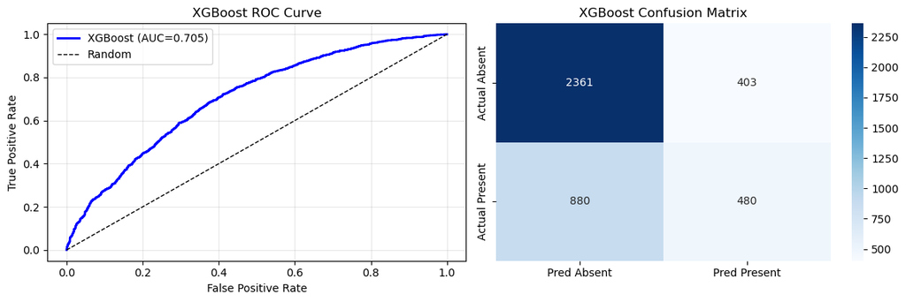

```
XGBoost Classification Report:
              precision    recall  f1-score   support

      Absent       0.73      0.85      0.79      2764
     Present       0.54      0.35      0.43      1360

    accuracy                           0.69      4124
   macro avg       0.64      0.60      0.61      4124
weighted avg       0.67      0.69      0.67      4124
```

```python
# Use the evaluation function for XGBoost
xgb_results = evaluate_model(
    model=xgb_model,
    X_test=X_test,
    y_test=y_test,
    model_name='XGBoost',
    save_fig=True,
    fig_filename='xgboost_evaluation.png'
)
```

## Section 5.5: Exercise - Build a Random Forest Model

**Learning Objective**: Practice building an alternative machine learning model and compare its performance with XGBoost.

### Background

Random Forest is another popular ensemble learning method that uses multiple decision trees. Unlike XGBoost's sequential boosting approach, Random Forest builds trees independently in parallel.

### Your Task

1. Import RandomForestClassifier from sklearn
2. Train a Random Forest model with the following parameters(training data is X_train and y_train):
   - `n_estimators=200` (number of trees)
   - `max_depth=15` (maximum depth of each tree)
   - `min_samples_split=10` (minimum samples to split a node)
   - `random_state=42` (for reproducibility)
3. Use the `evaluate_model()` function to evaluate your Random Forest(Testing data is X_test and y_test)

ANSWER BELOW

```
Training Random Forest model...
Random Forest trained with 200 trees

Random Forest Performance: AUC-ROC = 0.716
```

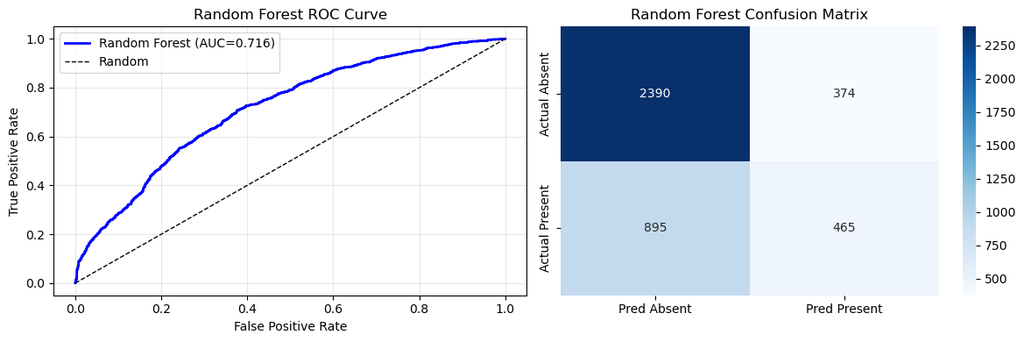

```
Random Forest Classification Report:
              precision    recall  f1-score   support

      Absent       0.73      0.86      0.79      2764
     Present       0.55      0.34      0.42      1360

    accuracy                           0.69      4124
   macro avg       0.64      0.60      0.61      4124
weighted avg       0.67      0.69      0.67      4124
```

```python
# ANSWER

# Step 1: Import RandomForestClassifier
from sklearn.ensemble import RandomForestClassifier

# Step 2: Create and train the Random Forest model
rf_model = RandomForestClassifier(
    n_estimators=200,        # Number of trees in the forest
    max_depth=15,            # Maximum depth of each tree
    min_samples_split=10,    # Minimum samples required to split a node
    random_state=42,         # For reproducibility
    n_jobs=-1                # Use all CPU cores for faster training
)

# Train the model
print("Training Random Forest model...")
rf_model.fit(X_train, y_train)
print(f"Random Forest trained with {rf_model.n_estimators} trees")

# Step 3: Evaluate the model using the evaluate_model() function
rf_results = evaluate_model(
    model=rf_model,
    X_test=X_test,
    y_test=y_test,
    model_name='Random Forest',
    save_fig=True,
    fig_filename='random_forest_evaluation.png'
)
```

## Section 6: Model Interpretation with SHAP

**SHAP values** show which features drive the model's predictions. This helps us understand the ecological relationships the model learned.

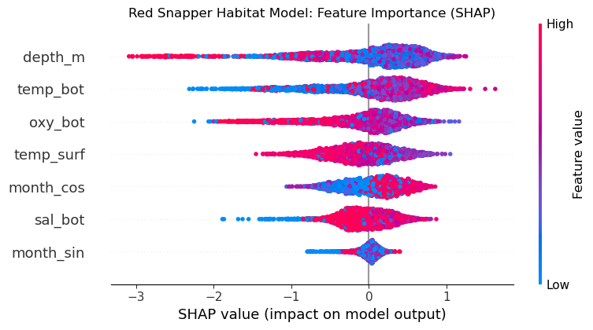

```
Interpretation: Features on top are most important. Red = high values, Blue = low values.
Positive SHAP = increases habitat suitability, Negative SHAP = decreases suitability.
```

```python
# Calculate and visualize SHAP values
explainer = shap.TreeExplainer(xgb_model)	# shap is a library for model explainability; this line creates a SHAP TreeExplainer object for the trained XGBoost model.
shap_values = explainer.shap_values(X_test)	# Computes the SHAP values for the test set features, quantifying each feature's contribution to the predictions.

# SHAP Summary Plot - shows feature importance and direction of effects
plt.figure(figsize=(10, 6))	# matplotlib.pyplot is used for plotting; this initializes a new figure with a specified size.
shap.summary_plot(shap_values, X_test, show=False)	# Generates a summary plot visualizing feature importance and the effect direction, using SHAP values and the test set features.
plt.title(f'{COMMON_NAME} Habitat Model: Feature Importance (SHAP)')	# Sets the title of the plot using the species common name.
plt.tight_layout()	# Adjusts plot spacing to prevent overlap.
plt.savefig(FIG_DIR / 'shap_summary.png', dpi=150)	# Saves the current figure to the designated FIG_DIR as a PNG file with 150 dpi resolution.
plt.show()	# Displays the figure.

print("Interpretation: Features on top are most important. Red = high values, Blue = low values.")
print("Positive SHAP = increases habitat suitability, Negative SHAP = decreases suitability.")
```

## Section 7: Habitat Suitability Predictions

Apply the trained model to predict habitat suitability at all survey locations. We plot the result out as hexbin heatmap

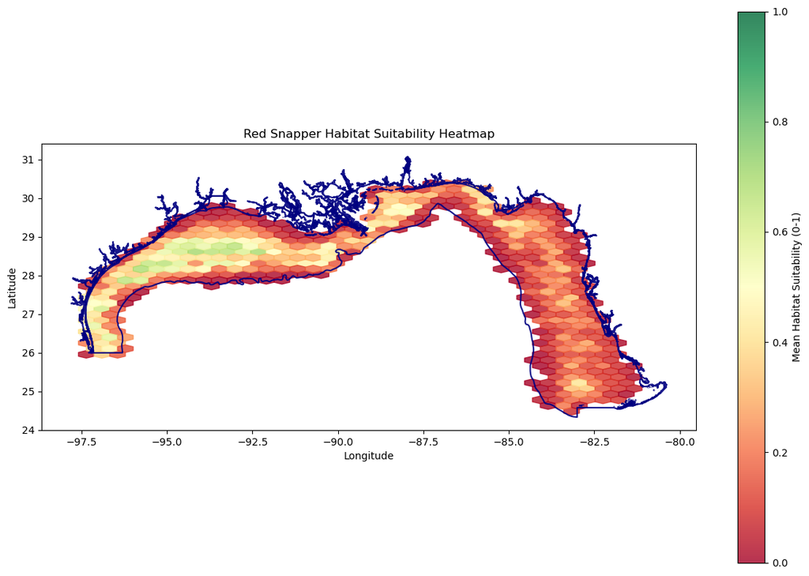

```python
df_predict = df_clean.copy()	# Creates a copy of the cleaned dataframe to retain the original data and allow modifications for prediction.
df_predict['habitat_prob'] = xgb_model.predict_proba(df_predict[FEATURE_COLS])[:, 1]	# Uses the trained XGBoost model to predict the probability of suitable habitat for each row, storing the result in a new column.
df_predict['habitat_class'] = (df_predict['habitat_prob'] > 0.5).astype(int)	# Converts habitat probability to a binary class where values above 0.5 are suitable (1) and others are unsuitable (0).

fig, ax = plt.subplots(1, 1, figsize=(12, 8))

# Add hexbin heatmap
hexbin = ax.hexbin(	# Creates a hexagonal binning plot on the axes to spatially aggregate predicted habitat probabilities.
    df_predict['longitude'],	# Supplies longitude data for the hexbin x-coordinates.
    df_predict['latitude'],	# Supplies latitude data for the hexbin y-coordinates.
    C=df_predict['habitat_prob'],	# Sets the value to be aggregated within each hex grid cell as predicted habitat probability.
    gridsize=35,	# Specifies the number of hexagons in the x-direction (resolution of spatial aggregation).
    cmap='RdYlGn',	# Applies the RdYlGn colormap for the hexbin color mapping, visualizing suitability from low to high.
    reduce_C_function=np.mean,	# Uses NumPy's mean function to compute the average predicted suitability in each hexagon.
    mincnt=1,	# Renders hexagons only where at least one point falls within a grid cell.
    alpha=0.8,	# Sets the transparency of the hexagons for visual effect.
    vmin=0,	# Sets the minimum colorbar value to 0 for normalization.
    vmax=1	# Sets the maximum colorbar value to 1 for normalization.
)

EFH_GDF.boundary.plot(ax=ax, color='navy', linewidth=1.5, alpha=0.9, zorder=2)	# Plots the Essential Fish Habitat (EFH) boundary on the axes, overlaying it above the hexbin layer for spatial context.

plt.colorbar(hexbin, ax=ax, label='Mean Habitat Suitability (0-1)')	# Adds a colorbar to the plot to indicate the scale of mean predicted habitat suitability.

ax.set_xlabel('Longitude')	# Sets the x-axis label to 'Longitude'.
ax.set_ylabel('Latitude')	# Sets the y-axis label to 'Latitude'.
ax.set_title(f'Red Snapper Habitat Suitability Heatmap') 	# Sets the plot title

plt.tight_layout()	# Adjusts subplot parameters to prevent overlapping plot elements.
plt.savefig(FIG_DIR / 'habitat_suitability_heatmap.png', dpi=150)	# Saves the figure to the designated output directory at 150 dots per inch resolution.
plt.show()	# Displays the plot in the notebook output.
```

## Section 8: Environment Condition Change Analysis

What happens to the habitat if conditions change? We simulate a +2°C warming and -1.5 ml/L oxygen decline and compare with the current baseline conditions. We test it on a single recent year(2022).

```
Using 2022 as baseline year: 445 survey locations
Average bottom temp: 25.1°C | Average bottom oxygen: 5.5 ml/L
```

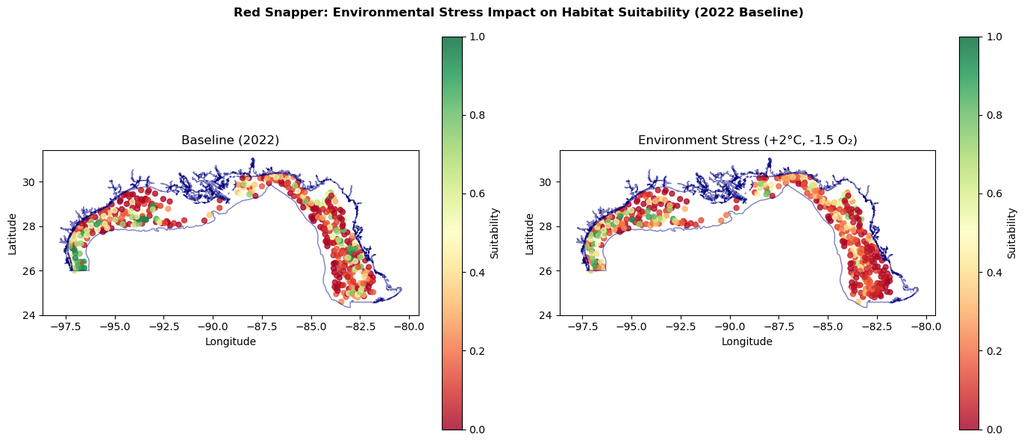

```
\Environmental Stress Impact Summary (2022 baseline):
  Baseline suitable: 87 locations
  After stress: 56 locations
  Habitat lost: 31 locations (35.6% reduction)
```

```python
# ENVIRONMENT CONDITION CHANGE SCENARIO SIMULATION

# Use a single recent year (2022) as the baseline for cleaner interpretation
SCENARIO_YEAR = 2022	# Defines the reference year for baseline conditions.
df_scenario = df_clean[df_clean['year'] == SCENARIO_YEAR].copy()	# Filters the cleaned data to only include observations from the scenario year.
print(f"Using {SCENARIO_YEAR} as baseline year: {len(df_scenario):,} survey locations")
print(f"Average bottom temp: {df_scenario['temp_bot'].mean():.1f}°C | Average bottom oxygen: {df_scenario['oxy_bot'].mean():.1f} ml/L")

# Baseline prediction (current conditions for the scenario year)
baseline_probs = xgb_model.predict_proba(df_scenario[FEATURE_COLS])[:, 1]	# Uses the XGBoost model to predict habitat suitability probabilities for the baseline year.

# Combined stress scenario: +2°C warming and -1.5 ml/L oxygen decline
df_stress = df_scenario.copy()	# Creates a copy of the scenario DataFrame
df_stress['temp_bot'] = df_stress['temp_bot'] + 2	# Increases the bottom temperature column by 2°C across all observations.
df_stress['temp_surf'] = df_stress['temp_surf'] + 2	# Increases the surface temperature column by 2°C for all locations.
df_stress['oxy_bot'] = np.clip(df_stress['oxy_bot'] - 1.5, 0.5, 10)	# Reduces bottom oxygen by 1.5 ml/L, ensuring values remain within the range 0.5-10.
stress_probs = xgb_model.predict_proba(df_stress[FEATURE_COLS])[:, 1]	# Predicts suitability probability using the modified stress scenario environmental features.

# Visualize comparison
fig, axes = plt.subplots(1, 2, figsize=(14, 6))	# Matplotlib is used for plotting; creates a figure with two subplots side by side.

for ax, probs, title in [(axes[0], baseline_probs, f'Baseline ({SCENARIO_YEAR})'),
                          (axes[1], stress_probs, 'Environment Stress (+2°C, -1.5 O₂)')]:	# Iterates over subplots and their corresponding data to plot baseline and stress scenario.
    EFH_GDF.boundary.plot(ax=ax, color='navy', linewidth=1, alpha=0.5)	# Plots the Essential Fish Habitat boundary on the map using GeoPandas.
    scatter = ax.scatter(df_scenario['longitude'], df_scenario['latitude'],
                        c=probs, cmap='RdYlGn', s=25, alpha=0.8, vmin=0, vmax=1)	# Creates a scatter plot of survey locations colored by predicted suitability.
    plt.colorbar(scatter, ax=ax, label='Suitability')	# Adds a colorbar to each subplot to display suitability values.
    ax.set_title(title); ax.set_xlabel('Longitude'); ax.set_ylabel('Latitude')	# Sets the title and axis labels for each subplot.

plt.suptitle(f'{COMMON_NAME}: Environmental Stress Impact on Habitat Suitability ({SCENARIO_YEAR} Baseline)', fontweight='bold')	# Sets a super title summarizing the plot's context with targeted species name.
plt.tight_layout()	# Adjusts subplot parameters to improve layout and prevent overlap.
plt.savefig(FIG_DIR / 'Environmental_Stress.png', dpi=150)	# Saves the visualization as a PNG file in the specified directory at 150 dpi.
plt.show()	# Displays the figure.

# Summary statistics
baseline_suit = (baseline_probs > 0.5).sum()	# Counts the number of baseline locations with suitability probability higher than 0.5.
stress_suit = (stress_probs > 0.5).sum()	# Counts the number of locations under stress scenario with suitability higher than 0.5.
lost = baseline_suit - stress_suit	# Calculates the loss in suitable habitat locations due to the environment scenario.
print(f"\Environmental Stress Impact Summary ({SCENARIO_YEAR} baseline):")
print(f"  Baseline suitable: {baseline_suit:,} locations")
print(f"  After stress: {stress_suit:,} locations")
print(f"  Habitat lost: {lost:,} locations ({100*lost/baseline_suit:.1f}% reduction)")
```